# NYC Electrcity Demand Prediction - ML Model Comparison

## Description

### Aim:

Compare performance of ML prediction models for electricity demand in New York City based on weather, time and date variables.

### Independent variables:

Weather (dewpoint, dry and wet bulb temperature, precipitation, humidity, pressure, visibility, wind speed), weekday/weekend and time (hourly)

### Models:

Linear regression (LR), decision tree (DT), random forest (RF), extreme gradient boosting (xgboost). (Models were chosen according to literature review)

### Evaluation metrics:

mean absolute error (MAE), mean squared error (MSE), root mean squared error (RMSE), R-squared (R2)

### Results:

#### Most important variables:

All models specified hour, temperature and weekday/weekend to be the best predictor variables. LR - hour, dry, wet, dew bulb temp, humidity, weekday/weekend, seasons. DT - hour, dry, wet, dew bulb temp, season, weekday/weekend. RF - hour, dry, dew and wet bulb temp, weekday/weekend, season. Xgb - hour, wet and dry temp, weekday/weekend

#### Model evaluation

LR is by far the worst predictor. Moderate results for DT. Both RF and xgboost performed similarly, achieving R2 values ~88% on test sets. However, it is likely that RF and xgboost models are overfitting to training data. The R2 scores for both were near 98-99% on training data. A regularisation term, feature extraction (such as PCA) or bagging methods could help to reduce the overfitting in future analysis.

## 1. Prepare data for modelling

(see data_wrangling.html for detailed data prep)

Split into test and train.

Select three years for train (2016, 2017, 2018) and one for test (2019)

```r
#split data into test and train
train <- master %>%
  filter(year(date) %in% c(2016, 2017, 2018)) %>%
  select(-date)
test <- master %>%
  filter(year(date) == 2019) %>%
  select(-date)
```

## 2. Model Building - LR, DT, RF

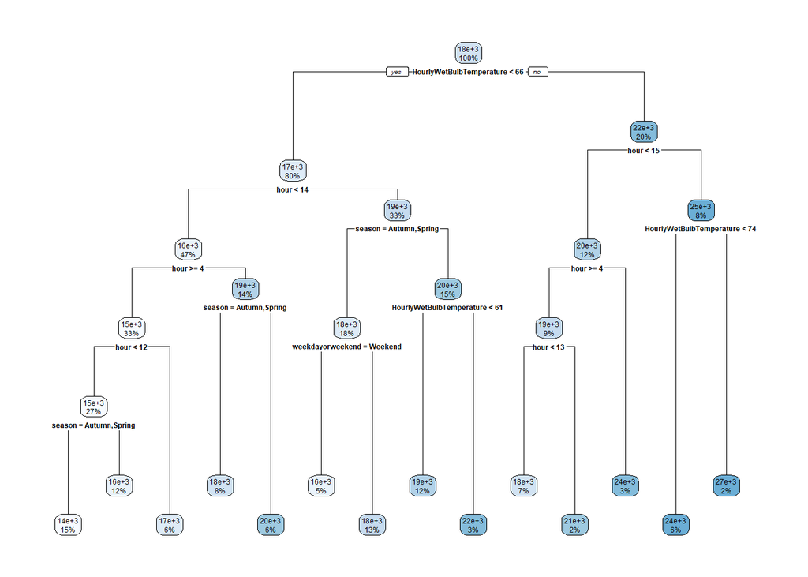

```r
# Linear Regression
lr <- lm(MWh ~ ., data = train)

# Decision Tree
dt <- rpart(MWh ~ ., data = train,
            minsplit = 10,
            minbucket = 2,
            cp = 0.01)
rpart.plot(dt)
```

```r
# Random Forest
rf <- randomForest(MWh ~ ., data = train
                   , ntree = 110)
#generate summaries
summary(lr)
```

```
##
## Call:
## lm(formula = MWh ~ ., data = train)
##
## Residuals:
##     Min      1Q  Median      3Q     Max
## -8199.8 -1818.6  -185.1  1610.1 12524.8
##
## Coefficients:
##                            Estimate Std. Error t value Pr(>|t|)
## (Intercept)               24132.287   2501.736   9.646  < 2e-16 ***
## hour                        126.911      2.523  50.303  < 2e-16 ***
## HourlyDewPointTemperature    38.844     12.624   3.077  0.00209 **
## HourlyDryBulbTemperature   -287.954     13.858 -20.779  < 2e-16 ***
## HourlyPrecipitation        2023.401    917.545   2.205  0.02745 *
## HourlyRelativeHumidity      -68.896      5.553 -12.408  < 2e-16 ***
## HourlyStationPressure      -165.832     80.889  -2.050  0.04036 *
## HourlyVisibility             24.240     10.836   2.237  0.02530 *
## HourlyWetBulbTemperature    314.094     16.167  19.428  < 2e-16 ***
## HourlyWindSpeed              -3.192      5.212  -0.612  0.54028
## weekdayorweekendWeekend   -1387.900     37.730 -36.785  < 2e-16 ***
## seasonSpring               -485.153     52.106  -9.311  < 2e-16 ***
## seasonSummer               3015.256     54.713  55.111  < 2e-16 ***
## seasonWinter               1426.331     59.965  23.786  < 2e-16 ***
## ---
## Signif. codes:  0 '***' 0.001 '**' 0.01 '*' 0.05 '.' 0.1 ' ' 1
##
## Residual standard error: 2761 on 26242 degrees of freedom
## Multiple R-squared:  0.3407, Adjusted R-squared:  0.3404
## F-statistic:  1043 on 13 and 26242 DF,  p-value: < 2.2e-16
```

```r
summary(dt)
```

```
## Call:
## rpart(formula = MWh ~ ., data = train, minsplit = 10, minbucket = 2,
##     cp = 0.01)
##   n= 26256
##
##            CP nsplit rel error    xerror        xstd
## 1  0.25461251      0 1.0000000 1.0000661 0.010677636
## 2  0.10267883      1 0.7453875 0.7455662 0.006586984
## 3  0.09057850      3 0.5400298 0.5390421 0.005913472
## 4  0.04584490      4 0.4494513 0.4484648 0.004592365
## 5  0.02754785      5 0.4036064 0.4026704 0.003874910
## 6  0.02053077      6 0.3760586 0.3751202 0.003658894
## 7  0.01596406      7 0.3555278 0.3581222 0.003616796
## 8  0.01476085      8 0.3395637 0.3471730 0.003515929
## 9  0.01405067      9 0.3248029 0.3281239 0.003385383
## 10 0.01249066     10 0.3107522 0.3105101 0.003314274
## 11 0.01230967     11 0.2982616 0.2998676 0.003246334
## 12 0.01166816     12 0.2859519 0.2902026 0.003135274
## 13 0.01000000     13 0.2742837 0.2766378 0.002916438
##
## Variable importance
##                      hour  HourlyWetBulbTemperature HourlyDewPointTemperature
##                        32                        25                        19
##  HourlyDryBulbTemperature                    season          weekdayorweekend
##                        13                         9                         1
##
## Node number 1: 26256 observations,    complexity param=0.2546125
##   mean=18184.3, MSE=1.155563e+07
##   left son=2 (21097 obs) right son=3 (5159 obs)
##   Primary splits:
##       HourlyWetBulbTemperature  < 66.25     to the left,  improve=0.2546125, (0 missing)
##       HourlyDryBulbTemperature  < 70.5      to the left,  improve=0.2307864, (0 missing)
##       HourlyDewPointTemperature < 62.5      to the left,  improve=0.2197908, (0 missing)
##       season                    splits as  LLRL, improve=0.1899194, (0 missing)
##       hour                      < 13.5      to the left,  improve=0.1738814, (0 missing)
##   Surrogate splits:
##       HourlyDewPointTemperature < 62.5      to the left,  agree=0.952, adj=0.757, (0 split)
##       HourlyDryBulbTemperature  < 71.5      to the left,  agree=0.905, adj=0.517, (0 split)
##       season                    splits as  LLRL, agree=0.833, adj=0.152, (0 split)
##       HourlyPrecipitation       < 0.32      to the left,  agree=0.804, adj=0.001, (0 split)
```

[output cut: 195 more lines]

```
##
## Node number 23: 772 observations
##   mean=21738.58, MSE=5187768
##
## Node number 24: 1914 observations
##   mean=18026.72, MSE=5316145
##
## Node number 25: 522 observations
##   mean=21044.35, MSE=6525083
##
## Node number 32: 3938 observations
##   mean=14196, MSE=1730637
##
## Node number 33: 3162 observations
##   mean=15755.09, MSE=2592426
```

```r
importance(rf)
```

```
##                           IncNodePurity
## hour                       118216994295
## HourlyDewPointTemperature   24289310691
## HourlyDryBulbTemperature    39859979397
## HourlyPrecipitation          1302321714
## HourlyRelativeHumidity       8028574400
## HourlyStationPressure       10139600893
## HourlyVisibility             3420631261
## HourlyWetBulbTemperature    55396776389
## HourlyWindSpeed              4589420596
## weekdayorweekend            11061511684
## season                      21022027323
```

### XGBoost - using random search to optimise parameters

```r
train_season <- train %>% select(season)
encoded_matrix_season <- as.data.frame(model.matrix(~ 0 + ., data = train_season))
train_weekdayorweekend <- train %>% select(weekdayorweekend)
encoded_matrix_weekdayorweekend <- as.data.frame(model.matrix(~ 0 + ., data = train_weekdayorweekend))
train_encoded <- cbind(train, encoded_matrix_season, encoded_matrix_weekdayorweekend) %>% select(-weekdayorweekend,-season)

n_samples <- 10

param_grid <- data.frame(
  nrounds = sample(100:300, n_samples, replace = TRUE),
  max_depth = sample(3:10, n_samples, replace = TRUE),
  eta = runif(n_samples, 0.01, 0.3),
  gamma = runif(n_samples, 0, 2),
  colsample_bytree = runif(n_samples, 0.7, 0.9),
  subsample = runif(n_samples, 0.7, 0.9),
  min_child_weight = sample(1:5, n_samples, replace = TRUE)
)

# Perform cross-validation with grid search
set.seed(123)
ctrl <- trainControl(method = "cv", number = 5)

# Define the model
model <- train(
  x = train_encoded[, -10],
  y = train_encoded[, 10],
  method = "xgbTree",
  trControl = ctrl,
  tuneGrid = param_grid,
  metric = "RMSE"
)

# Print the best model and its parameters
best_model <- model$bestTune
print(best_model)
```

```
##   nrounds max_depth       eta    gamma colsample_bytree min_child_weight
## 4     250         9 0.1537973 1.087485        0.7356722                3
##   subsample
## 4 0.8423073
```

```r
xgb <- xgboost(
  data = as.matrix(train_encoded[, -10]),
  label = train_encoded[, 10],
  nrounds = best_model$nrounds,
  max_depth = best_model$max_depth,
  eta = best_model$eta,
  gamma = best_model$gamma,
  colsample_bytree = best_model$colsample_bytree,
  subsample = best_model$subsample,
  min_child_weight = best_model$min_child_weight
)
xgb_var_info <- xgb.importance(model = xgb)
print(xgb_var_info)
```

```
##                       Feature        Gain       Cover   Frequency
##  1:                      hour 0.438450583 0.126297079 0.123169669
##  2:  HourlyWetBulbTemperature 0.323909344 0.123147520 0.070804829
##  3:  HourlyDryBulbTemperature 0.078833000 0.132089993 0.120583933
##  4:   weekdayorweekendWeekday 0.037919904 0.018097511 0.028118028
##  5:     HourlyStationPressure 0.021151211 0.151841820 0.179789891
##  6:              seasonSummer 0.019941670 0.012902621 0.012116018
##  7:              seasonSpring 0.016994292 0.011455212 0.014066402
##  8: HourlyDewPointTemperature 0.012404316 0.132397961 0.135418668
##  9:              seasonAutumn 0.012359597 0.010464991 0.016578259
## 10:    HourlyRelativeHumidity 0.011592053 0.109255249 0.118648325
## 11:              seasonWinter 0.008375291 0.008223297 0.008850604
## 12:           HourlyWindSpeed 0.007306814 0.100457132 0.095539237
## 13:          HourlyVisibility 0.005855540 0.028869514 0.045110005
## 14:   weekdayorweekendWeekend 0.002621950 0.002948922 0.005969355
## 15:       HourlyPrecipitation 0.002284434 0.031551177 0.025236780
```

## 3. Evaluate model performance on training sets

```r
train_predictions <- train %>% select(MWh)
models <- list(lr, dt, rf)

for (i in 1:length(models)) {
  predictions <- as.data.frame(predict(models[[i]], newdata = train))
  model_name <- c("LR", "DT", "RF")[i]
  names(predictions)[1] <- paste(model_name,"train",sep = "_")
  train_predictions <- cbind(train_predictions, predictions)
}

xgb_train_predictions <- as.data.frame(predict(xgb, as.matrix(train_encoded[, -10])))
names(xgb_train_predictions)[1] <- "XGB_train"
train_predictions <- cbind(train_predictions, xgb_train_predictions)

# Extract true values and model estimates
true_values <- train_predictions[, 1]
model_estimates <- train_predictions[, 2:5]

# Create data frame to store results
evaluation_results <- data.frame(Model = character(0), MAE = numeric(0), MSE = numeric(0), RMSE = numeric(0), R2 = numeric(0))

# List of model names
model_names <- c("linear_regression", "decision_tree", "random_forest", "XGBoost")

# Loop through the models and calculate evaluation metrics
for (i in 1:length(model_names)) {
  model_name <- model_names[i]
  predictions <- model_estimates[, i]

  # Calculate evaluation metrics
  mae <- mean(abs(predictions - true_values))
  mse <- mean((predictions - true_values)^2)
  rmse <- sqrt(mse)
  r_squared <- 1 - (sum((predictions - true_values)^2) / sum((mean(true_values) - true_values)^2))

  # Add results to the data frame
  result_row <- data.frame(Model = model_name, MAE = mae, MSE = mse, RMSE = rmse, R2 = r_squared)
  evaluation_results <- rbind(evaluation_results, result_row)
}


print(evaluation_results)
```

```
##               Model       MAE        MSE      RMSE        R2
## 1 linear_regression 2138.6545 7618845.39 2760.2256 0.3406808
## 2     decision_tree 1361.4394 3169520.17 1780.3146 0.7257163
## 3     random_forest  317.8388  201326.13  448.6938 0.9825777
## 4           XGBoost  182.6527   67906.01  260.5878 0.9941236
```

### Plot training results

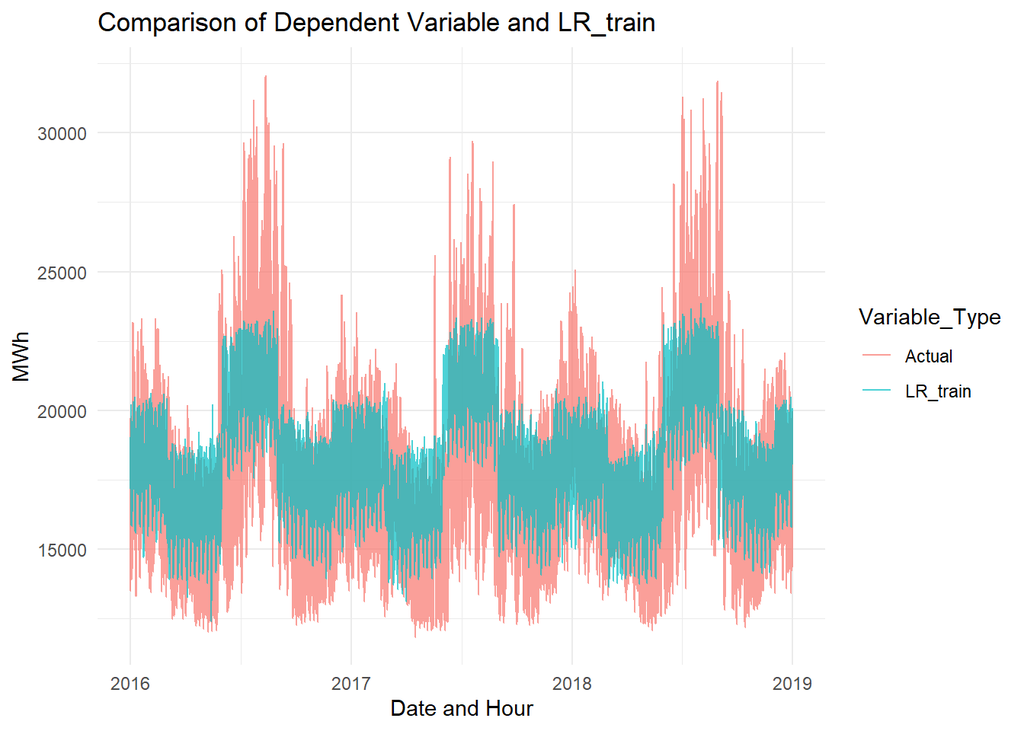

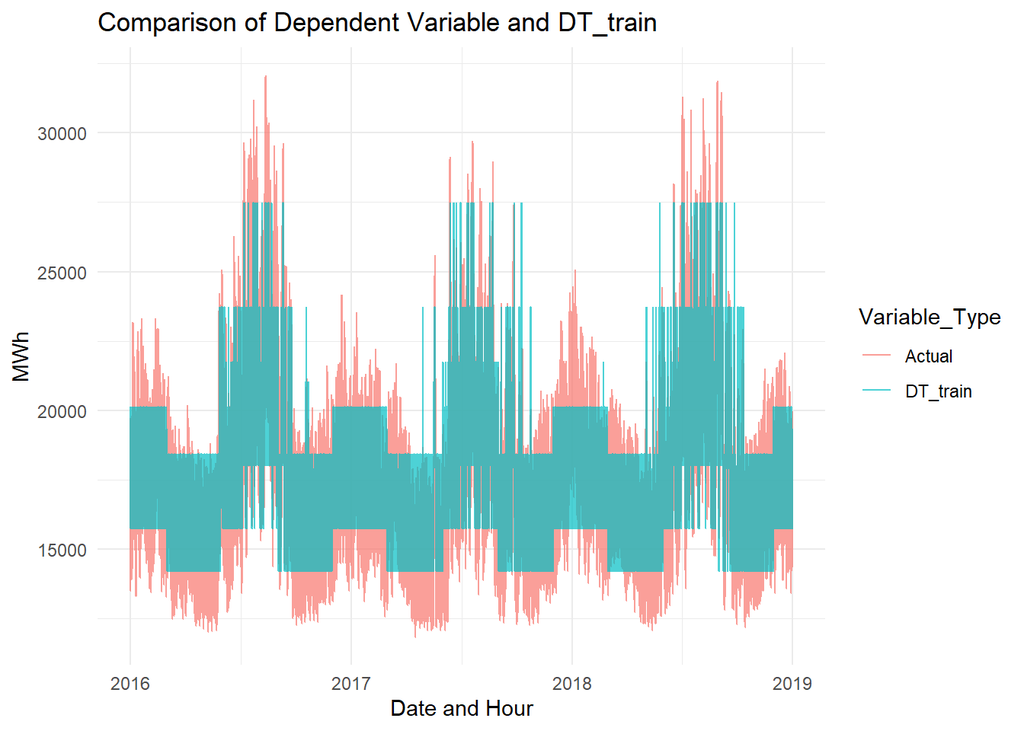

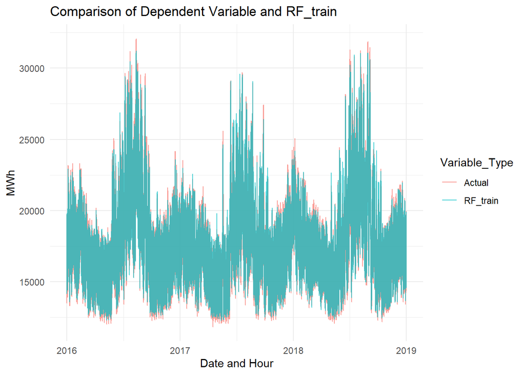

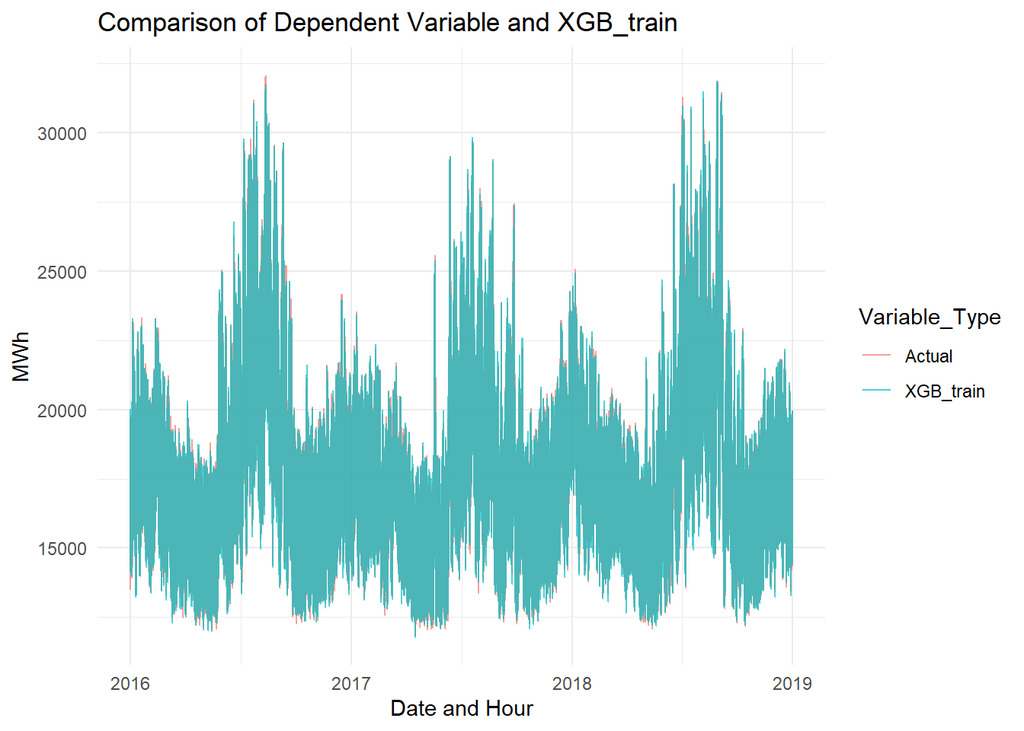

```r
library(ggplot2)
plot <- master %>%
  filter(year(date) %in% c(2016, 2017, 2018)) %>%
  select(date, hour)
plot <- cbind(plot, train_predictions)
# Convert Date and Hour columns to a single datetime column
plot$DateTime <- ymd(plot$date) + hours(plot$hour - 1)
plot <- plot %>% select(-date,-hour)
plot <- plot %>% rename(Actual = MWh)

# Gather the Model columns into a long format for easy plotting
df_long <- tidyr::gather(plot, key = "Variable_Type", value = "Value", -DateTime)

# Create separate line plots for each Model
model_names <- unique(df_long$Variable_Type)

plots <- lapply(model_names, function(model_name) {
  if (model_name != "Actual") {
    p <- ggplot(data = df_long[df_long$Variable_Type %in% c(model_name, "Actual"), ],
                aes(x = DateTime, y = Value, color = Variable_Type)) +
      geom_line(alpha = 0.7) +
      labs(title = paste("Comparison of Dependent Variable and", model_name),
           x = "Date and Hour",
           y = "MWh") +
      theme_minimal()
    return(p)
  }
})

# Print or save the plots
for (i in 1:length(plots)) {
  if (!is.null(plots[[i]])) {
    print(plots[[i]])
  }
}
```

## 4. Evaluate model performance on test data

```r
test_predictions <- test %>% select(MWh)
models <- list(lr, dt, rf)

for (i in 1:length(models)) {
  predictions <- as.data.frame(predict(models[[i]], newdata = test))
  model_name <- c("LR", "DT", "RF")[i]
  names(predictions)[1] <- paste(model_name,"test",sep = "_")
  test_predictions <- cbind(test_predictions, predictions)
}

test_season <- test %>% select(season)
test_encoded_matrix_season <- as.data.frame(model.matrix(~ 0 + ., data = test_season))
test_weekdayorweekend <- test %>% select(weekdayorweekend)
test_encoded_matrix_weekdayorweekend <- as.data.frame(model.matrix(~ 0 + ., data = test_weekdayorweekend))
test_encoded <- cbind(test, test_encoded_matrix_season, test_encoded_matrix_weekdayorweekend) %>% select(-weekdayorweekend,-season)

xgb_test_predictions <- as.data.frame(predict(xgb, as.matrix(test_encoded[, -10])))
names(xgb_test_predictions)[1] <- "XGB_test"
test_predictions <- cbind(test_predictions, xgb_test_predictions)

# Extract true values and model estimates
true_values <- test_predictions[, 1]
model_estimates <- test_predictions[, 2:5]

# Initialize a data frame to store results
evaluation_results <- data.frame(Model = character(0), MAE = numeric(0), MSE = numeric(0), RMSE = numeric(0), R2 = numeric(0))

# List of model names
model_names <- c("linear_regression", "decision_tree", "random_forest", "XGBoost")

# Loop through the models and calculate evaluation metrics
for (i in 1:length(model_names)) {
  model_name <- model_names[i]
  predictions <- model_estimates[, i]

  # Calculate evaluation metrics
  mae <- mean(abs(predictions - true_values))
  mse <- mean((predictions - true_values)^2)
  rmse <- sqrt(mse)
  r_squared <- 1 - (sum((predictions - true_values)^2) / sum((mean(true_values) - true_values)^2))

  # Add results to the data frame
  result_row <- data.frame(Model = model_name, MAE = mae, MSE = mse, RMSE = rmse, R2 = r_squared)
  evaluation_results <- rbind(evaluation_results, result_row)
}

print(evaluation_results)
```

```
##               Model       MAE     MSE     RMSE        R2
## 1 linear_regression 2075.5251 6853914 2617.998 0.3297025
## 2     decision_tree 1401.1931 3332844 1825.608 0.6740553
## 3     random_forest  838.9328 1256015 1120.721 0.8771646
## 4           XGBoost  815.8033 1236968 1112.191 0.8790273
```

### Plot test results vs actual

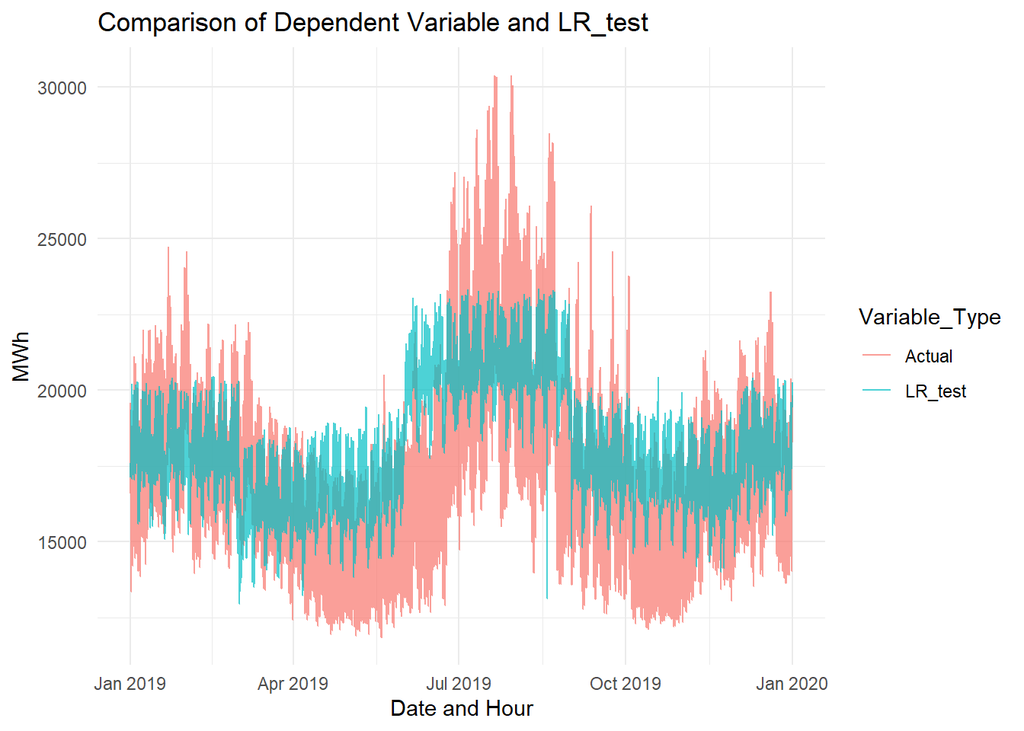

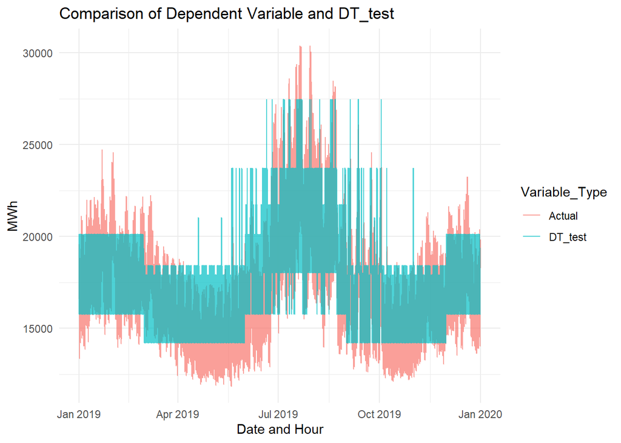

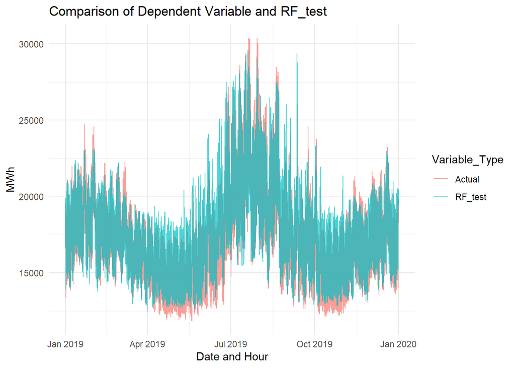

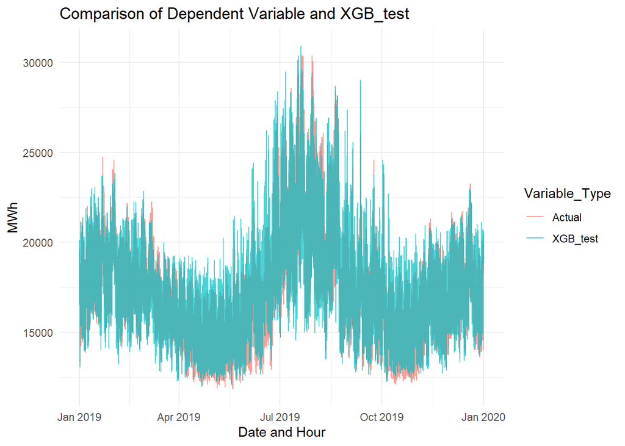

```r
plot_test <- master %>%
  filter(year(date) %in% c(2019)) %>%
  select(date, hour)
plot_test <- cbind(plot_test, test_predictions)
# Convert Date and Hour columns to a single datetime column
plot_test$DateTime <- ymd(plot_test$date) + hours(plot_test$hour - 1)
plot_test <- plot_test %>% select(-date,-hour)
plot_test <- plot_test %>% rename(Actual = MWh)

# Gather the Model columns into a long format for easy plotting
df_long <- tidyr::gather(plot_test, key = "Variable_Type", value = "Value", -DateTime)

# Create separate line plots for each Model
model_names <- unique(df_long$Variable_Type)

plots <- lapply(model_names, function(model_name) {
  if (model_name != "Actual") {
    p <- ggplot(data = df_long[df_long$Variable_Type %in% c(model_name, "Actual"), ],
                aes(x = DateTime, y = Value, color = Variable_Type)) +
      geom_line(alpha = 0.7) +
      labs(title = paste("Comparison of Dependent Variable and", model_name),
           x = "Date and Hour",
           y = "MWh") +
      theme_minimal()
    return(p)
  }
})

# Print or save the plots
for (i in 1:length(plots)) {
  if (!is.null(plots[[i]])) {
    print(plots[[i]])
  }
}
```